# Trabalho AEDV gapminder_parte B

Paula Eduarda de Lima.

2023-05-09

```r
if(!require(utf8)) install.packages("utf8")
library(utf8)
Sys.setlocale("LC_ALL", "pt_br.utf-8")
```

```
## [1] "LC_COLLATE=pt_br.utf-8;LC_CTYPE=pt_br.utf-8;LC_MONETARY=pt_br.utf-8;LC_NUMERIC=C;LC_TIME=pt_br.utf-8"
```

```r
if(!require(extrafont)) install.packages("extrafont")
```

```
## Registering fonts with R
```

```r
library(extrafont)
font_import()
```

```
## Importing fonts may take a few minutes, depending on the number of fonts and the speed of the system.
## Continue? [y/n]
```

```
## Exiting.
```

```r
loadfonts(device = "win")
```

# Instalando e importando as bibliotecas

```r
if(!require(tidyverse)) install.packages("tidyverse")
if(!require(ggthemes)) install.packages("ggthemes")
```

```r
if(!require(ggplot2)) install.packages("ggplot2")
if(!require(tidyverse)) install.packages("tidyverse")
```

```r
library(tidyverse)
library(ggplot2)
library(gapminder)
library(ggthemes)
```

# Os dados

Usaremos os dados da tabela gapminder para fazer nossos gráficos:

```r
gapminder
```

```
## # A tibble: 1,704 × 6
##    country     continent  year lifeExp      pop gdpPercap
##    <fct>       <fct>     <int>   <dbl>    <int>     <dbl>
##  1 Afghanistan Asia       1952    28.8  8425333      779.
##  2 Afghanistan Asia       1957    30.3  9240934      821.
##  3 Afghanistan Asia       1962    32.0 10267083      853.
##  4 Afghanistan Asia       1967    34.0 11537966      836.
##  5 Afghanistan Asia       1972    36.1 13079460      740.
##  6 Afghanistan Asia       1977    38.4 14880372      786.
##  7 Afghanistan Asia       1982    39.9 12881816      978.
##  8 Afghanistan Asia       1987    40.8 13867957      852.
##  9 Afghanistan Asia       1992    41.7 16317921      649.
## 10 Afghanistan Asia       1997    41.8 22227415      635.
## # ℹ 1,694 more rows
```

# Gráficos

- **1º Gráfico:** A seguir esta o gráfico do exemplo do livro:

```r
graf <- ggplot(data = gapminder, mapping = aes(x= gdpPercap, y = lifeExp)) +
  geom_point() +
  geom_smooth(method = "lm") +
  scale_x_log10(labels= scales::dollar)
```

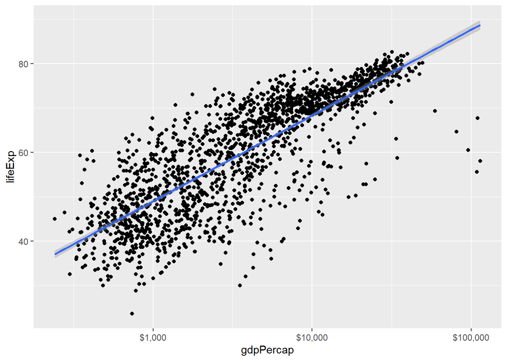

```r
graf
```

Modificações desse gráfico:

- adicionar cor aos pontos

-Mudar o tema de fundo

-adicionar transparência aos pontos

- transformar a linha de tendência de azul para preto

- colocar rótulos dos eixos x e y como ‘Pib per capita’ e ‘Expectativa de vida em anos’, respectivamente

- colocar o título ‘Crescimento Econômico e Expectativa de Vida’ no gráfico

- por fim adicionar a fonte como ‘Gapminder’. Resultando no seguinte novo gráfico:

```r
graf <- ggplot(data = gapminder, mapping = aes(x= gdpPercap, y = lifeExp)) +
  geom_point(color = "brown", alpha = 0.5) +
  geom_smooth(method = "lm", color = "black") +
  scale_x_log10(labels= scales::dollar) +
  theme_igray() +
  labs(x = "Pib per capita", y = "Expectativa de vida em anos",
       title = "Crescimento Econômico e Expectativa de Vida",
       caption = "Fonte: Gapminder.")
```

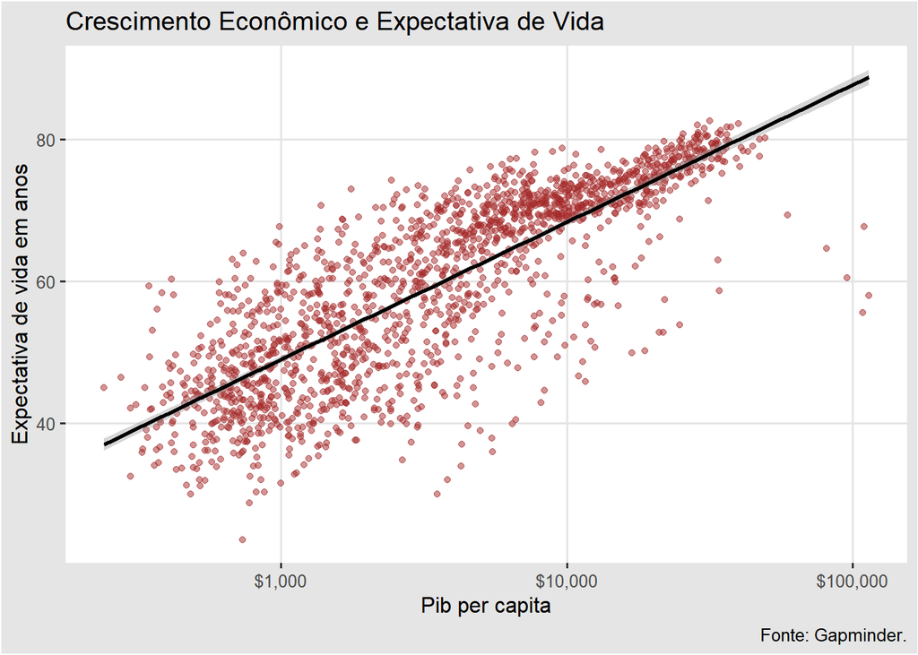

```r
graf
```

- **2º Gráfico:**

Exemplo do livro:

```r
graf <- ggplot(data = gapminder, mapping = aes(x= gdpPercap, y = lifeExp, color = "purple")) +
  geom_point() +
  geom_smooth(method = "loess") +
  scale_x_log10()
```

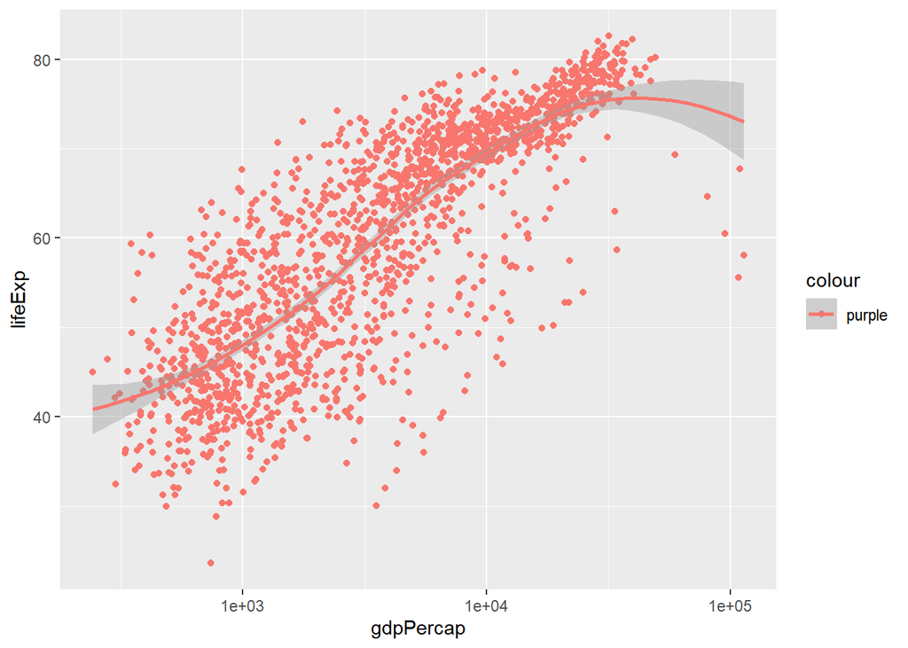

```r
graf
```

Modificações: - adicionar a cor verde aos pontos

-adicionar transparência aos pontos

- transformar a linha de tendência em cinza

- Alterar o tema de fundo

```r
graf <- ggplot(data = gapminder, mapping = aes(x= gdpPercap, y = lifeExp )) +
  geom_point(color = "darkgreen", alpha = 0.3) +
  theme_par() +
  geom_smooth(method = "loess", color = "gray80") +
  scale_x_log10()
```

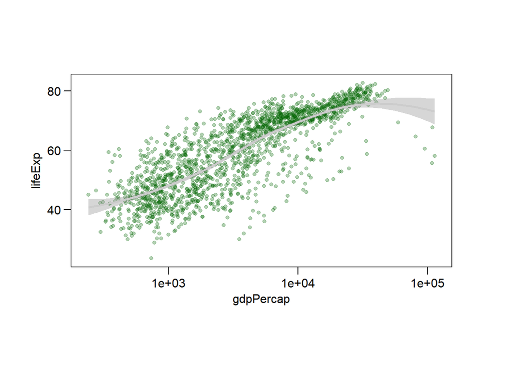

```r
graf
```

- **3º Gráfico:**

No exemplo do livro estava indicado para usar size = 8, no entanto aperece esse erro:

“Warning: Using `size` aesthetic for lines was deprecated in ggplot2 3.4.0. Please use `linewidth` instead.”

Tendo isso em vista, eu substitui, como recomendado, por linewidth = 1, de maneira a ficar parecido com o esperado no livro.

```r
graf <- ggplot(data = gapminder, mapping = aes(x= gdpPercap, y = lifeExp)) +
  geom_point(alpha = 0.3) +
  geom_smooth(color = "orange", se = FALSE, linewidth = 1, method = "lm") +
  scale_x_log10()
```

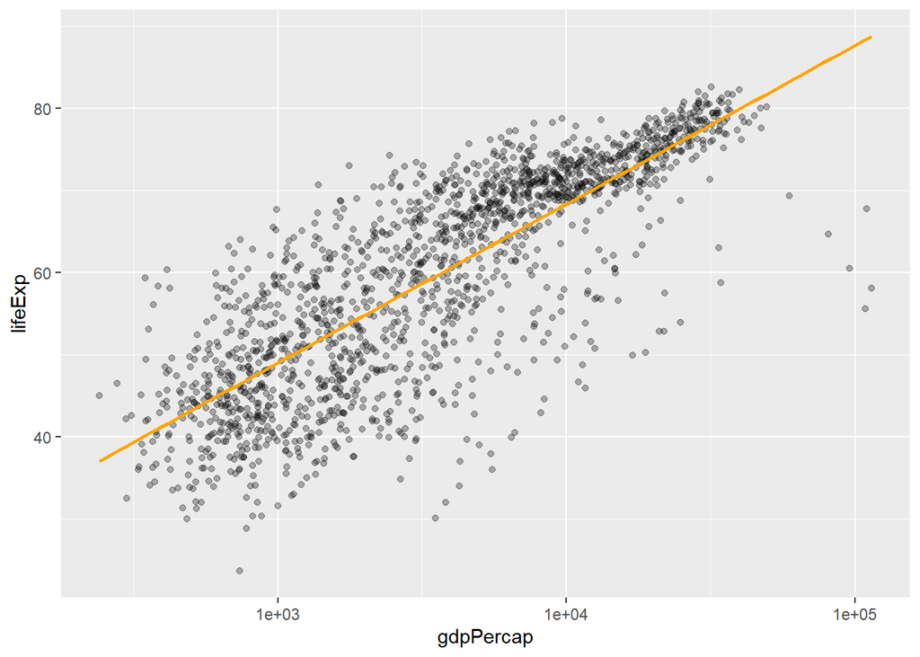

```r
graf
```

Modificações no gráfico:

- adicionar cor dos pontos relacionada aos continentes

-tirar toda a transparência dos pontos

- transformar a linha de tendência para preto

-colocar o tamanho dos ponto para 0.8

-colocar o rótulo de cores no topo

```r
graf <- ggplot(data = gapminder, mapping = aes(x= gdpPercap, y = lifeExp, color = continent)) +
  geom_point(size = 0.8) +
  theme(legend.position = "top") +
  geom_smooth(color = "black", se = FALSE, linewidth = 1, method = "lm") +
  scale_x_log10()
```

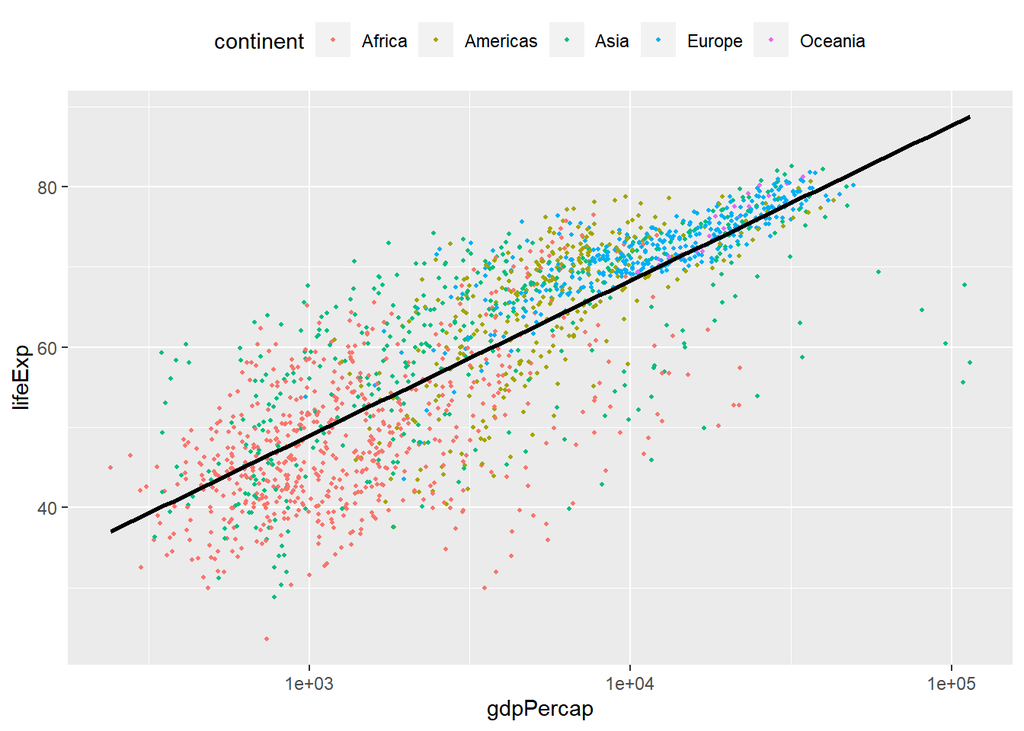

```r
graf
```

- **4º Gráfico:**

```r
graf <- ggplot(data = gapminder, mapping = aes(x= gdpPercap, y = lifeExp)) +

  geom_point(alpha = 0.3) +

  geom_smooth(method = "gam") +

  scale_x_log10(labels= scales::dollar) +

  labs(x = "GDP Per Capita", y = "Life Expectancy in Years",
       title = "Economic Growth and Life Expectancy",
       subtitle = "Data points are contry-years",
       caption = "Source: Gapminder.")
```

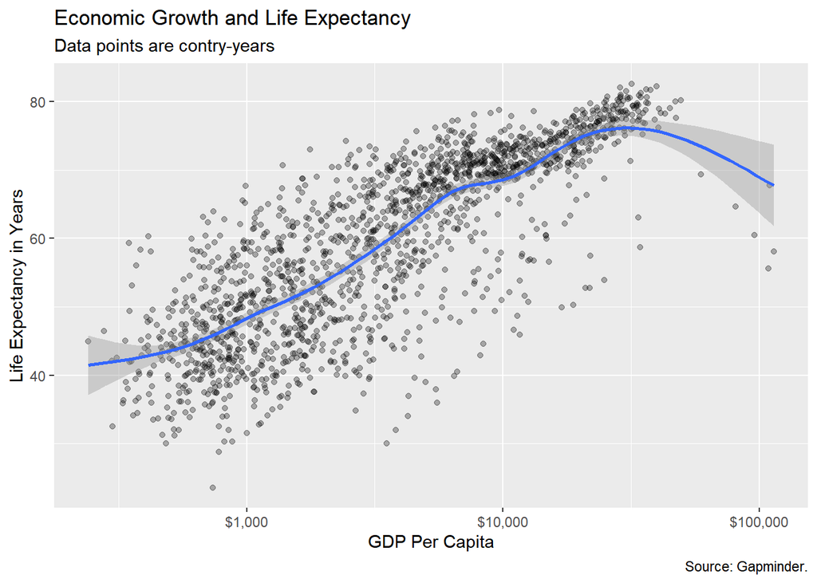

```r
graf
```

Modificações no gráfico:

- Modificar os rótulos e títulos para uma versão traduzida em português

- Mudar o tema de fundo

- adicionar cor dos pontos relacionada aos continentes

- mudar a paleta de cores para PRGn

-tirar toda a transparência dos pontos

- transformar a linha de tendência para cinza

```r
graf <- ggplot(data = gapminder, mapping = aes(x= gdpPercap, y = lifeExp, color = continent, fill = continent)) +

  scale_color_brewer(palette = "PRGn") +

  geom_point() +

  theme_classic() +

  geom_smooth(color = "gray", method = "gam") +

  scale_x_log10(labels= scales::dollar) +

  labs(x = "PIB per capita", y = "Expectativa de vida em anos",
       title = "Crescimento econômico e expectativa de vida",
       subtitle = "Os pontos dos dados são os países",
       caption = "Fonte: Gapminder.")
```

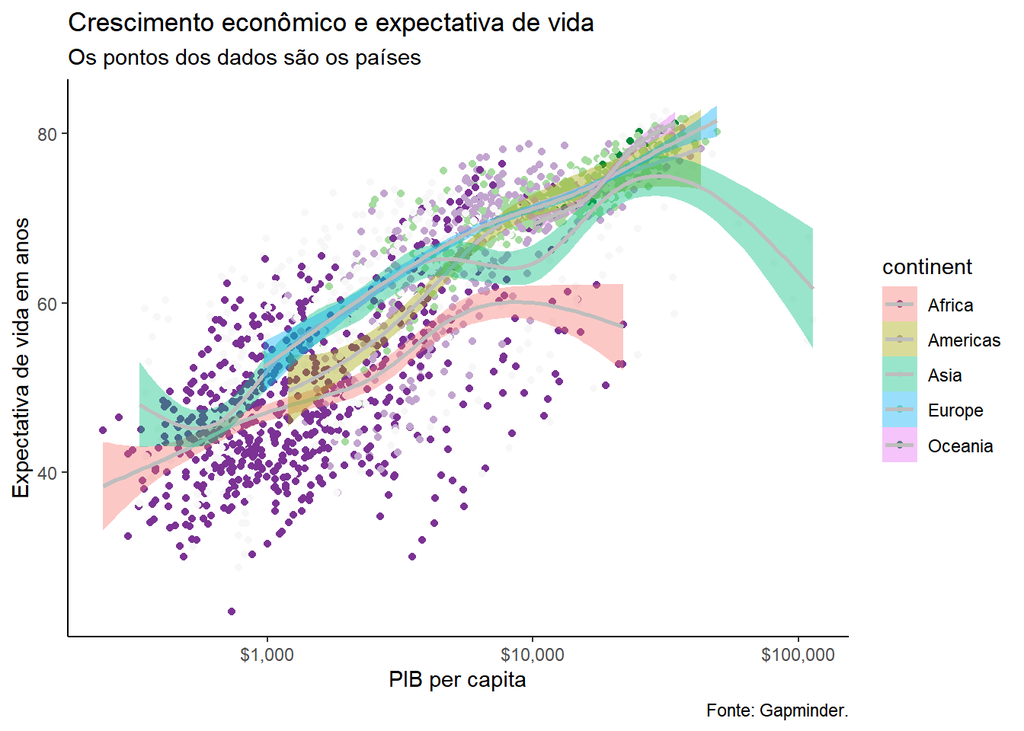

```r
graf
```

- **5º Gráfico:**

```r
graf <- ggplot(data = gapminder, mapping = aes(x= gdpPercap, y = lifeExp, color = continent, fill = continent)) +
  geom_point() +
  geom_smooth(method = "loess") +
  scale_x_log10(labels= scales::dollar)
```

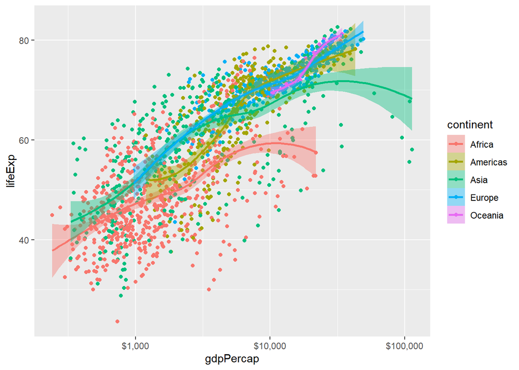

```r
graf
```

Modificações no gráfico:

- Mudar o tema de fundo

- adicionar cor dos pontos relacionada aos continentes

-tirar toda a transparência dos pontos

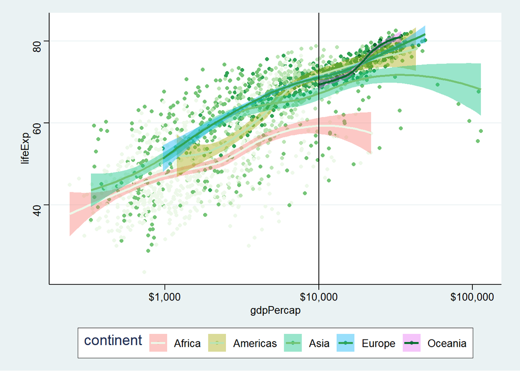

```r
graf <- ggplot(data = gapminder, mapping = aes(x= gdpPercap, y = lifeExp, color = continent, fill = continent)) +
  scale_color_brewer(palette = "Bupu") +
  theme_stata(base_size = 11, base_family = "sans", scheme = "s2color")+
  geom_point() +
  geom_smooth(method = "loess") +
  scale_x_log10(labels= scales::dollar)+
  geom_vline(xintercept = 10000)
graf
```

- **6º Gráfico:**

```r
graf <- ggplot(data = gapminder, mapping = aes(x= gdpPercap, y = lifeExp)) +

  geom_point(mapping = aes(color = log(pop))) +

  scale_x_log10()
```

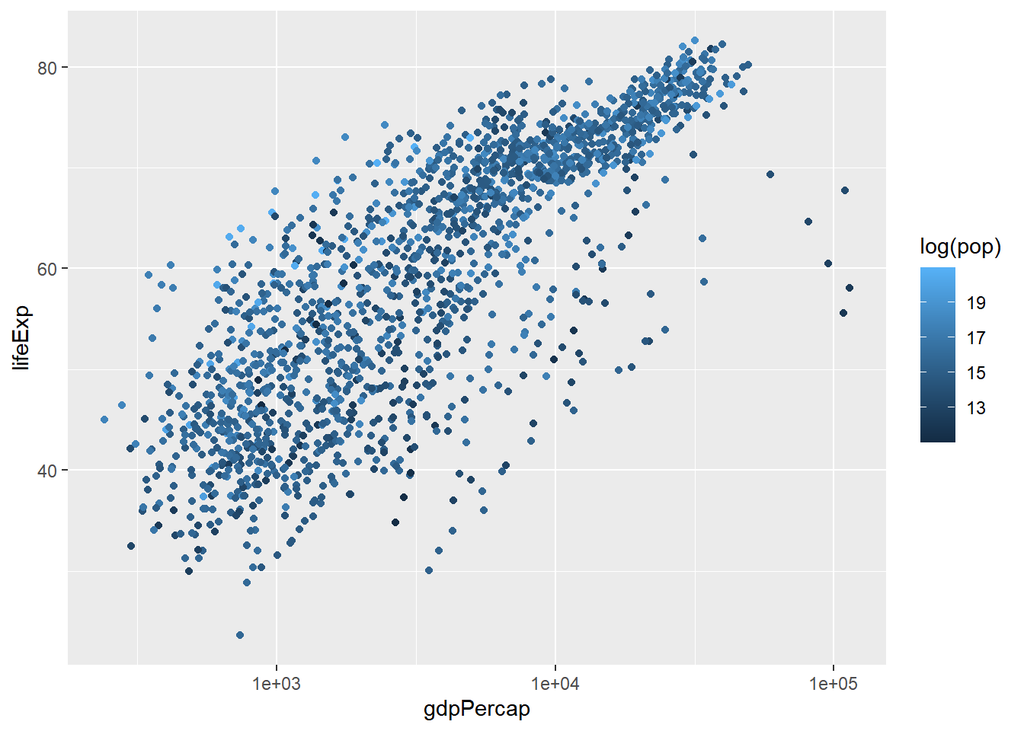

```r
graf
```

Modificações no gráfico:

- Mudar o tema de fundo

```r
graf <- ggplot(data = gapminder, mapping = aes(x= gdpPercap, y = lifeExp)) +

  geom_point(mapping = aes(color = log(pop))) +

  theme_solarized_2()+


  scale_x_log10()
```

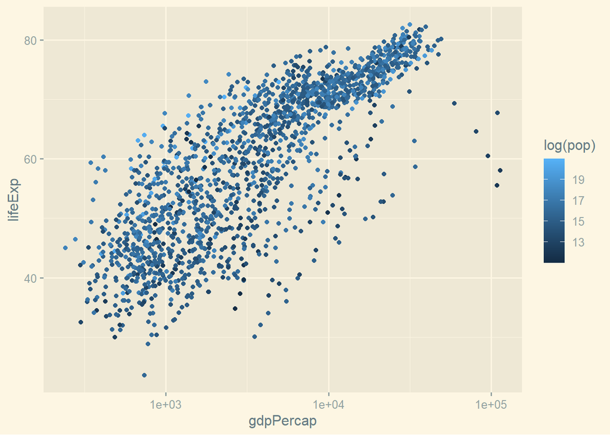

```r
graf
```